# 1. Loading and Reading the data

1.1 loading the obtained DDOS attack datset from Kaggles # each csv hold the diffrent type of DDOS attacks collected on diffrent dates

```python
import pandas as pd

# df1=pd.read_csv('./02-14-2018.csv')
# df2=pd.read_csv('./02-15-2018.csv')
# df3=pd.read_csv('./02-16-2018.csv')
# df4=pd.read_csv('./02-20-2018.csv')
# df5=pd.read_csv('./02-21-2018.csv')
df6=pd.read_csv('./02-22-2018.csv')
df7=pd.read_csv('./02-23-2018.csv')
# df8=pd.read_csv('./02-28-2018.csv')
# df9=pd.read_csv('./03-01-2018.csv')
# df10=pd.read_csv('./03-02-2018.csv')
```

```python
# print('the shape of dataframe1',df1.shape) #reading the file shape for each data frames
# print('the shape of dataframe2',df2.shape)
# print('the shape of dataframe3',df3.shape)
# print('the shape of dataframe4',df4.shape)
# print('the shape of dataframe5',df5.shape)
print('the shape of dataframe6',df6.shape)
print('the shape of dataframe7',df7.shape)
# print('the shape of dataframe8',df8.shape)
# print('the shape of dataframe9',df9.shape)
# print('the shape of dataframe10',df10.shape)
```

```
the shape of dataframe6 (1048575, 80)
the shape of dataframe7 (1048575, 80)
```

1.2 Reading the dataset and removing the outliers

```python
# print('1.The Type and quantity of attach present in df1 \n',df1['Label'].value_counts() )
# print('\n 2.The Type and quantity of attach present in df2 \n ',df2['Label'].value_counts() )
# print('\n 3.The Type and quantity of attach present in df3 \n',df3['Label'].value_counts() )
# print('\n 4. The Type and quantity of attach present in df4 \n',df4['Label'].value_counts() )
# print('\n 5. The Type and quantity of attach present in df5 \n',df5['Label'].value_counts() )
print('\n 6. The Type and quantity of attach present in df6 \n',df6['Label'].value_counts() )
print('\n 7. The Type and quantity of attach present in df7 \n',df7['Label'].value_counts() )
# print('\n 8. The Type and quantity of attach present in df8 \n',df8['Label'].value_counts() )
# print('\n 9. The Type and quantity of attach present in df9 \n',df9['Label'].value_counts() )
# print('\n 10. The Type and quantity of attach present in df10 \n',df10['Label'].value_counts() )
```

```
 6. The Type and quantity of attach present in df6
 Benign              1048213
Brute Force -Web        249
Brute Force -XSS         79
SQL Injection            34
Name: Label, dtype: int64

 7. The Type and quantity of attach present in df7
 Benign              1048009
Brute Force -Web        362
Brute Force -XSS        151
SQL Injection            53
Name: Label, dtype: int64
```

next codebox we will use df.drop(df.loc[df['Label']=='Label'].index,inplace=True) # the column value = 'Label' does not account for any type of DDOS attack, hence removing this

```python
# df3.drop(df3.loc[df3['Label']=='Label'].index,inplace=True)
# df8.drop(df8.loc[df8['Label']=='Label'].index,inplace=True)
# df9.drop(df9.loc[df9['Label']=='Label'].index,inplace=True)
```

```python
# Strat_df1=df1.groupby('Label', group_keys=False).apply(lambda x: x.sample(10000)) # Applying Stratified Sampling on the datasets
# Strat_df2=df2.groupby('Label', group_keys=False).apply(lambda x: x.sample(10000))
# Strat_df3=df3.groupby('Label', group_keys=False).apply(lambda x: x.sample(10000))
# Strat_df4=df4.groupby('Label', group_keys=False).apply(lambda x: x.sample(10000))
# del df1,df2,df3,df4

# print('The Stratified Sample of Dataset1 \n ', Strat_df1['Label'].value_counts()) #obtaning equal no of class sample to process EDA
# print('='*100)
# print('The Stratified Sample of Dataset2 \n ', Strat_df2['Label'].value_counts())
# print('='*100)
# print('The Stratified Sample of Dataset3 \n ', Strat_df3['Label'].value_counts())
# print('='*100)
# print('The Stratified Sample of Dataset4 \n ', Strat_df4['Label'].value_counts())

# print('*'*100)
# print('*'*100)

# #web attcks in these dataframes are less than 10000 hence we are randomly sampling the points here
N=10000
# Strat_df5=df5.head(N)
Strat_df6=df6.head(N)
Strat_df7=df7.head(N)
# del df5,df6,df7


# print('The Stratified Sample of Dataset5 \n ', Strat_df5['Label'].value_counts())
# print('='*100)
print('The Stratified Sample of Dataset6 \n ', Strat_df6['Label'].value_counts())
print('='*100)
print('The Stratified Sample of Dataset7 \n ', Strat_df7['Label'].value_counts())

print('*'*100)
print('*'*100)
# Applying Stratified Sampling on the datasets
# Strat_df8=df8.groupby('Label', group_keys=False).apply(lambda x: x.sample(10000))
# Strat_df9=df9.groupby('Label', group_keys=False).apply(lambda x: x.sample(10000))
# Strat_df10=df10.groupby('Label', group_keys=False).apply(lambda x: x.sample(10000))
# del df8,df9,df10
# #obtaning equal no of class sample to process EDA
# print('The Stratified Sample of Dataset8 \n ', Strat_df8['Label'].value_counts())
# print('='*100)
# print('The Stratified Sample of Dataset9 \n ', Strat_df9['Label'].value_counts())
# print('='*100)
# print('The Stratified Sample of Dataset10 \n ', Strat_df10['Label'].value_counts())
# print('='*100)
```

```
The Stratified Sample of Dataset6
  Benign              9638
Brute Force -Web     249
Brute Force -XSS      79
SQL Injection         34
Name: Label, dtype: int64
====================================================================================================
The Stratified Sample of Dataset7
  Benign              9434
Brute Force -Web     362
Brute Force -XSS     151
SQL Injection         53
Name: Label, dtype: int64
```

1.4 Concatenating all the sampled to a single dataset

```python
final_dataset=pd.concat([Strat_df6,Strat_df7])
del Strat_df6,Strat_df7
# final_dataset=pd.concat([final_dataset,Strat_df3])
# del Strat_df3
# final_dataset=pd.concat([final_dataset,Strat_df4])
# del Strat_df4
# final_dataset=pd.concat([final_dataset,Strat_df5])
# del Strat_df5
# final_dataset=pd.concat([final_dataset,Strat_df6])
# del Strat_df6
# final_dataset=pd.concat([final_dataset,Strat_df7])
# del Strat_df7
# final_dataset=pd.concat([final_dataset,Strat_df8])
# del Strat_df8
# final_dataset=pd.concat([final_dataset,Strat_df9])
# del Strat_df9
# final_dataset=pd.concat([final_dataset,Strat_df10])
# del Strat_df10
```

```python
final_dataset.shape
```

```
(20000, 80)
```

```python
final_dataset.sample(20)
```

|  | Dst Port | Protocol | Timestamp | Flow Duration | Tot Fwd Pkts | Tot Bwd Pkts | TotLen Fwd Pkts | TotLen Bwd Pkts | Fwd Pkt Len Max | Fwd Pkt Len Min | ... | Fwd Seg Size Min | Active Mean | Active Std | Active Max | Active Min | Idle Mean | Idle Std | Idle Max | Idle Min | Label |
| --- | --- | --- | --- | --- | --- | --- | --- | --- | --- | --- | --- | --- | --- | --- | --- | --- | --- | --- | --- | --- | --- |
| 1871 | 500 | 17 | 23/02/2018 04:58:14 | 89479780 | 6 | 0 | 3000 | 0 | 500 | 500 | ... | 8 | 4.000389e+06 | 0.000000 | 4000389 | 4000389 | 2.136985e+07 | 1.528109e+07 | 41990335 | 7200397 | Benign |
| 1747 | 500 | 17 | 22/02/2018 04:51:48 | 89479474 | 6 | 0 | 3000 | 0 | 500 | 500 | ... | 8 | 4.000332e+06 | 0.000000 | 4000332 | 4000332 | 2.136979e+07 | 1.528109e+07 | 41990256 | 7200228 | Benign |
| 4767 | 443 | 6 | 22/02/2018 10:10:39 | 60140916 | 13 | 12 | 1052 | 1682 | 394 | 0 | ... | 20 | 2.937383e+04 | 43353.126796 | 117868 | 11633 | 9.994004e+06 | 1.959308e+04 | 10003756 | 9954711 | Benign |
| 867 | 500 | 17 | 22/02/2018 12:11:12 | 89479575 | 6 | 0 | 3000 | 0 | 500 | 500 | ... | 8 | 4.000247e+06 | 0.000000 | 4000247 | 4000247 | 2.136983e+07 | 1.528106e+07 | 41990308 | 7200386 | Benign |
| 4990 | 3389 | 6 | 23/02/2018 10:10:45 | 4057303 | 13 | 8 | 1440 | 1731 | 725 | 0 | ... | 20 | 0.000000e+00 | 0.000000 | 0 | 0 | 0.000000e+00 | 0.000000e+00 | 0 | 0 | Benign |
| 6295 | 443 | 6 | 23/02/2018 10:44:13 | 180 | 2 | 0 | 0 | 0 | 0 | 0 | ... | 20 | 0.000000e+00 | 0.000000 | 0 | 0 | 0.000000e+00 | 0.000000e+00 | 0 | 0 | Benign |
| 7575 | 443 | 6 | 23/02/2018 11:15:49 | 172 | 2 | 0 | 0 | 0 | 0 | 0 | ... | 20 | 0.000000e+00 | 0.000000 | 0 | 0 | 0.000000e+00 | 0.000000e+00 | 0 | 0 | Benign |
| 9913 | 80 | 6 | 23/02/2018 01:05:54 | 118065210 | 20 | 16 | 1307 | 2118 | 432 | 0 | ... | 20 | 2.810278e+05 | 893915.347817 | 2976284 | 11441 | 9.991770e+06 | 4.011420e+04 | 10003926 | 9870821 | Benign |
| 1114 | 80 | 6 | 23/02/2018 01:19:11 | 56797401 | 203 | 104 | 56330 | 189999 | 680 | 0 | ... | 20 | 0.000000e+00 | 0.000000 | 0 | 0 | 0.000000e+00 | 0.000000e+00 | 0 | 0 | Brute Force -XSS |
| 451 | 80 | 6 | 22/02/2018 10:38:39 | 5001360 | 5 | 3 | 646 | 364 | 646 | 0 | ... | 20 | 0.000000e+00 | 0.000000 | 0 | 0 | 0.000000e+00 | 0.000000e+00 | 0 | 0 | Brute Force -Web |
| 858 | 500 | 17 | 23/02/2018 11:58:59 | 89479630 | 6 | 0 | 3000 | 0 | 500 | 500 | ... | 8 | 4.000279e+06 | 0.000000 | 4000279 | 4000279 | 2.136984e+07 | 1.528110e+07 | 41990357 | 7200345 | Benign |
| 1645 | 500 | 17 | 23/02/2018 03:35:42 | 89479759 | 6 | 0 | 3000 | 0 | 500 | 500 | ... | 8 | 4.000283e+06 | 0.000000 | 4000283 | 4000283 | 2.136987e+07 | 1.528106e+07 | 41990356 | 7200464 | Benign |
| 5556 | 445 | 6 | 22/02/2018 10:37:50 | 263733 | 3 | 1 | 0 | 0 | 0 | 0 | ... | 20 | 0.000000e+00 | 0.000000 | 0 | 0 | 0.000000e+00 | 0.000000e+00 | 0 | 0 | Benign |
| 8556 | 80 | 6 | 23/02/2018 11:45:39 | 79 | 2 | 0 | 0 | 0 | 0 | 0 | ... | 20 | 0.000000e+00 | 0.000000 | 0 | 0 | 0.000000e+00 | 0.000000e+00 | 0 | 0 | Benign |
| 9326 | 443 | 6 | 22/02/2018 01:39:56 | 115844786 | 19 | 16 | 1823 | 425 | 1213 | 0 | ... | 20 | 4.680450e+04 | 89603.883177 | 331335 | 20875 | 9.606926e+06 | 1.349641e+06 | 10010119 | 5323456 | Benign |
| 6306 | 80 | 6 | 23/02/2018 10:44:15 | 139 | 2 | 0 | 0 | 0 | 0 | 0 | ... | 20 | 0.000000e+00 | 0.000000 | 0 | 0 | 0.000000e+00 | 0.000000e+00 | 0 | 0 | Benign |
| 7696 | 443 | 6 | 23/02/2018 11:18:30 | 1730 | 3 | 0 | 77 | 0 | 46 | 0 | ... | 20 | 0.000000e+00 | 0.000000 | 0 | 0 | 0.000000e+00 | 0.000000e+00 | 0 | 0 | Benign |
| 9100 | 445 | 6 | 22/02/2018 01:29:59 | 829508 | 7 | 5 | 364 | 582 | 103 | 0 | ... | 20 | 0.000000e+00 | 0.000000 | 0 | 0 | 0.000000e+00 | 0.000000e+00 | 0 | 0 | Benign |
| 3656 | 443 | 6 | 22/02/2018 09:07:41 | 118168610 | 16 | 14 | 1007 | 3521 | 361 | 0 | ... | 20 | 2.695445e+05 | 182015.649438 | 398249 | 140840 | 5.874433e+07 | 1.701433e+05 | 58864643 | 58624024 | Benign |
| 1104 | 500 | 17 | 23/02/2018 01:15:24 | 89479730 | 6 | 0 | 3000 | 0 | 500 | 500 | ... | 8 | 4.000317e+06 | 0.000000 | 4000317 | 4000317 | 2.136985e+07 | 1.528110e+07 | 41990385 | 7200332 | Benign |

20 rows × 80 columns

```python
final_dataset.sample(10)
```

|  | Dst Port | Protocol | Timestamp | Flow Duration | Tot Fwd Pkts | Tot Bwd Pkts | TotLen Fwd Pkts | TotLen Bwd Pkts | Fwd Pkt Len Max | Fwd Pkt Len Min | ... | Fwd Seg Size Min | Active Mean | Active Std | Active Max | Active Min | Idle Mean | Idle Std | Idle Max | Idle Min | Label |
| --- | --- | --- | --- | --- | --- | --- | --- | --- | --- | --- | --- | --- | --- | --- | --- | --- | --- | --- | --- | --- | --- |
| 2946 | 80 | 6 | 23/02/2018 08:15:40 | 116058683 | 16 | 14 | 459 | 913 | 448 | 0 | ... | 20 | 2.759909e+04 | 21541.018246 | 92544 | 20928 | 1.000471e+07 | 1.716897e+04 | 10010064 | 9952949 | Benign |
| 1589 | 49238 | 6 | 23/02/2018 03:17:19 | 5012529 | 2 | 2 | 0 | 0 | 0 | 0 | ... | 32 | 0.000000e+00 | 0.000000 | 0 | 0 | 0.000000e+00 | 0.000000e+00 | 0 | 0 | Benign |
| 1179 | 80 | 6 | 23/02/2018 01:32:38 | 56654964 | 203 | 104 | 56330 | 190002 | 680 | 0 | ... | 20 | 0.000000e+00 | 0.000000 | 0 | 0 | 0.000000e+00 | 0.000000e+00 | 0 | 0 | Brute Force -XSS |
| 9799 | 80 | 6 | 22/02/2018 01:46:36 | 115515545 | 16 | 14 | 445 | 706 | 434 | 0 | ... | 20 | 1.302548e+05 | 92265.112451 | 407492 | 94087 | 1.001628e+07 | 2.959418e+04 | 10094304 | 9999646 | Benign |
| 3918 | 80 | 6 | 22/02/2018 09:17:03 | 115939289 | 16 | 14 | 447 | 788 | 436 | 0 | ... | 20 | 1.690745e+04 | 18602.178407 | 72995 | 11247 | 9.995924e+06 | 1.499108e+04 | 10001414 | 9950744 | Benign |
| 5075 | 80 | 6 | 22/02/2018 10:24:21 | 852 | 3 | 4 | 148 | 243 | 148 | 0 | ... | 20 | 0.000000e+00 | 0.000000 | 0 | 0 | 0.000000e+00 | 0.000000e+00 | 0 | 0 | Benign |
| 577 | 80 | 6 | 23/02/2018 10:42:42 | 56723607 | 153 | 104 | 54995 | 72494 | 646 | 0 | ... | 20 | 0.000000e+00 | 0.000000 | 0 | 0 | 0.000000e+00 | 0.000000e+00 | 0 | 0 | Brute Force -Web |
| 6536 | 80 | 6 | 22/02/2018 11:08:30 | 5917468 | 4 | 4 | 97 | 231 | 97 | 0 | ... | 20 | 0.000000e+00 | 0.000000 | 0 | 0 | 0.000000e+00 | 0.000000e+00 | 0 | 0 | Benign |
| 8896 | 3389 | 6 | 23/02/2018 11:57:50 | 4126955 | 14 | 8 | 1441 | 1731 | 725 | 0 | ... | 20 | 0.000000e+00 | 0.000000 | 0 | 0 | 0.000000e+00 | 0.000000e+00 | 0 | 0 | Benign |
| 1852 | 500 | 17 | 23/02/2018 04:50:36 | 89479623 | 6 | 0 | 3000 | 0 | 500 | 500 | ... | 8 | 4.000366e+06 | 0.000000 | 4000366 | 4000366 | 2.136981e+07 | 1.528110e+07 | 41990314 | 7200320 | Benign |

10 rows × 80 columns

# 2.Data PreProcessing

```python
final_dataset.columns
```

```
Index(['Dst Port', 'Protocol', 'Timestamp', 'Flow Duration', 'Tot Fwd Pkts',
       'Tot Bwd Pkts', 'TotLen Fwd Pkts', 'TotLen Bwd Pkts', 'Fwd Pkt Len Max',
       'Fwd Pkt Len Min', 'Fwd Pkt Len Mean', 'Fwd Pkt Len Std',
       'Bwd Pkt Len Max', 'Bwd Pkt Len Min', 'Bwd Pkt Len Mean',
       'Bwd Pkt Len Std', 'Flow Byts/s', 'Flow Pkts/s', 'Flow IAT Mean',
       'Flow IAT Std', 'Flow IAT Max', 'Flow IAT Min', 'Fwd IAT Tot',
       'Fwd IAT Mean', 'Fwd IAT Std', 'Fwd IAT Max', 'Fwd IAT Min',
       'Bwd IAT Tot', 'Bwd IAT Mean', 'Bwd IAT Std', 'Bwd IAT Max',
       'Bwd IAT Min', 'Fwd PSH Flags', 'Bwd PSH Flags', 'Fwd URG Flags',
       'Bwd URG Flags', 'Fwd Header Len', 'Bwd Header Len', 'Fwd Pkts/s',
       'Bwd Pkts/s', 'Pkt Len Min', 'Pkt Len Max', 'Pkt Len Mean',
       'Pkt Len Std', 'Pkt Len Var', 'FIN Flag Cnt', 'SYN Flag Cnt',
       'RST Flag Cnt', 'PSH Flag Cnt', 'ACK Flag Cnt', 'URG Flag Cnt',
       'CWE Flag Count', 'ECE Flag Cnt', 'Down/Up Ratio', 'Pkt Size Avg',
       'Fwd Seg Size Avg', 'Bwd Seg Size Avg', 'Fwd Byts/b Avg',
       'Fwd Pkts/b Avg', 'Fwd Blk Rate Avg', 'Bwd Byts/b Avg',
       'Bwd Pkts/b Avg', 'Bwd Blk Rate Avg', 'Subflow Fwd Pkts',
       'Subflow Fwd Byts', 'Subflow Bwd Pkts', 'Subflow Bwd Byts',
       'Init Fwd Win Byts', 'Init Bwd Win Byts', 'Fwd Act Data Pkts',
       'Fwd Seg Size Min', 'Active Mean', 'Active Std', 'Active Max',
       'Active Min', 'Idle Mean', 'Idle Std', 'Idle Max', 'Idle Min', 'Label'],
      dtype='object')
```

```python
final_dataset['Label'].value_counts()
```

```
Benign              19072
Brute Force -Web      611
Brute Force -XSS      230
SQL Injection          87
Name: Label, dtype: int64
```

```python
final_dataset.dtypes
```

```
Dst Port           int64
Protocol           int64
Timestamp         object
Flow Duration      int64
Tot Fwd Pkts       int64
                  ...
Idle Mean        float64
Idle Std         float64
Idle Max           int64
Idle Min           int64
Label             object
Length: 80, dtype: object
```

```python
import numpy as np #converting the timestamp is int

final_dataset['Timestamp'] = pd.to_datetime(final_dataset['Timestamp']).astype(np.int64)
```

```python
#converting all the numerical features datatype from object to float
final_dataset = final_dataset.astype({'Dst Port': 'float', 'Protocol': 'float','Dst Port':'float', 'Protocol':'float', 'Timestamp':'float', 'Flow Duration':'float', 'Tot Fwd Pkts':'float',
'Tot Bwd Pkts':'float', 'TotLen Fwd Pkts':'float', 'TotLen Bwd Pkts':'float', 'Fwd Pkt Len Max':'float'})

final_dataset = final_dataset.astype({'Fwd Pkt Len Min':'float', 'Fwd Pkt Len Mean':'float', 'Fwd Pkt Len Std':'float','Bwd Pkt Len Max':'float', 'Bwd Pkt Len Min':'float', 'Bwd Pkt Len Mean':'float',
'Bwd Pkt Len Std':'float', 'Flow Byts/s':'float', 'Flow Pkts/s':'float', 'Flow IAT Mean':'float'})

final_dataset = final_dataset.astype({'Flow IAT Std':'float', 'Flow IAT Max':'float', 'Flow IAT Min':'float', 'Fwd IAT Tot':'float','Fwd IAT Mean':'float', 'Fwd IAT Std':'float', 'Fwd IAT Max':'float',
'Fwd IAT Min':'float','Bwd IAT Tot':'float', 'Bwd IAT Mean':'float', 'Bwd IAT Std':'float', 'Bwd IAT Max':'float'})
```

```python
final_dataset = final_dataset.astype({'Bwd IAT Min':'float', 'Fwd PSH Flags':'float', 'Bwd PSH Flags':'float', 'Fwd URG Flags':'float','Bwd URG Flags':'float', 'Fwd Header Len':'float', 'Bwd Header Len':'float',
'Fwd Pkts/s':'float','Bwd Pkts/s':'float', 'Pkt Len Min':'float', 'Pkt Len Max':'float', 'Pkt Len Mean':'float'})

final_dataset = final_dataset.astype({'Pkt Len Std':'float', 'Pkt Len Var':'float', 'FIN Flag Cnt':'float', 'SYN Flag Cnt':'float','RST Flag Cnt':'float', 'PSH Flag Cnt':'float', 'ACK Flag Cnt':'float',
'URG Flag Cnt':'float','CWE Flag Count':'float', 'ECE Flag Cnt':'float', 'Down/Up Ratio':'float', 'Pkt Size Avg':'float'})

final_dataset = final_dataset.astype({'Fwd Seg Size Avg':'float', 'Bwd Seg Size Avg':'float', 'Fwd Byts/b Avg':'float','Fwd Pkts/b Avg':'float', 'Fwd Blk Rate Avg':'float', 'Bwd Byts/b Avg':'float',
'Bwd Pkts/b Avg':'float', 'Bwd Blk Rate Avg':'float', 'Subflow Fwd Pkts':'float','Subflow Fwd Byts':'float', 'Subflow Bwd Pkts':'float', 'Subflow Bwd Byts':'float'})


final_dataset = final_dataset.astype({'Init Fwd Win Byts':'float', 'Init Bwd Win Byts':'float', 'Fwd Act Data Pkts':'float','Fwd Seg Size Min':'float', 'Active Mean':'float', 'Active Std':'float', 'Active Max':'float',
'Active Min':'float', 'Idle Mean':'float', 'Idle Std':'float', 'Idle Max':'float', 'Idle Min':'float'})
```

```python
pd.set_option('display.max_rows',None) #listing all the rows
final_dataset.dtypes
```

```
Dst Port             float64
Protocol             float64
Timestamp            float64
Flow Duration        float64
Tot Fwd Pkts         float64
Tot Bwd Pkts         float64
TotLen Fwd Pkts      float64
TotLen Bwd Pkts      float64
Fwd Pkt Len Max      float64
Fwd Pkt Len Min      float64
Fwd Pkt Len Mean     float64
Fwd Pkt Len Std      float64
Bwd Pkt Len Max      float64
Bwd Pkt Len Min      float64
Bwd Pkt Len Mean     float64
Bwd Pkt Len Std      float64
Flow Byts/s          float64
Flow Pkts/s          float64
Flow IAT Mean        float64
Flow IAT Std         float64
Flow IAT Max         float64
Flow IAT Min         float64
Fwd IAT Tot          float64
Fwd IAT Mean         float64
Fwd IAT Std          float64
Fwd IAT Max          float64
Fwd IAT Min          float64
Bwd IAT Tot          float64
Bwd IAT Mean         float64
Bwd IAT Std          float64
Bwd IAT Max          float64
Bwd IAT Min          float64
Fwd PSH Flags        float64
Bwd PSH Flags        float64
Fwd URG Flags        float64
Bwd URG Flags        float64
Fwd Header Len       float64
Bwd Header Len       float64
Fwd Pkts/s           float64
Bwd Pkts/s           float64
```

[output cut: 26 more lines]

```
Subflow Bwd Byts     float64
Init Fwd Win Byts    float64
Init Bwd Win Byts    float64
Fwd Act Data Pkts    float64
Fwd Seg Size Min     float64
Active Mean          float64
Active Std           float64
Active Max           float64
Active Min           float64
Idle Mean            float64
Idle Std             float64
Idle Max             float64
Idle Min             float64
Label                 object
dtype: object
```

```python
# final_dataset.drop(['Flow ID', 'Src IP', 'Src Port', 'Dst IP'], axis=1, inplace=True)
```

checking for Null and Inf values

```python
final_dataset[final_dataset.isnull().any(axis=1)]
```

|  | Dst Port | Protocol | Timestamp | Flow Duration | Tot Fwd Pkts | Tot Bwd Pkts | TotLen Fwd Pkts | TotLen Bwd Pkts | Fwd Pkt Len Max | Fwd Pkt Len Min | ... | Fwd Seg Size Min | Active Mean | Active Std | Active Max | Active Min | Idle Mean | Idle Std | Idle Max | Idle Min | Label |
| --- | --- | --- | --- | --- | --- | --- | --- | --- | --- | --- | --- | --- | --- | --- | --- | --- | --- | --- | --- | --- | --- |
| 3445 | 49738.0 | 6.0 | 1.519290e+18 | 0.0 | 2.0 | 0.0 | 0.0 | 0.0 | 0.0 | 0.0 | ... | 20.0 | 0.0 | 0.0 | 0.0 | 0.0 | 0.0 | 0.0 | 0.0 | 0.0 | Benign |
| 3767 | 49812.0 | 6.0 | 1.519291e+18 | 0.0 | 2.0 | 0.0 | 0.0 | 0.0 | 0.0 | 0.0 | ... | 20.0 | 0.0 | 0.0 | 0.0 | 0.0 | 0.0 | 0.0 | 0.0 | 0.0 | Benign |
| 3819 | 49862.0 | 6.0 | 1.519291e+18 | 0.0 | 2.0 | 0.0 | 0.0 | 0.0 | 0.0 | 0.0 | ... | 20.0 | 0.0 | 0.0 | 0.0 | 0.0 | 0.0 | 0.0 | 0.0 | 0.0 | Benign |
| 3916 | 49844.0 | 6.0 | 1.519291e+18 | 0.0 | 2.0 | 0.0 | 0.0 | 0.0 | 0.0 | 0.0 | ... | 20.0 | 0.0 | 0.0 | 0.0 | 0.0 | 0.0 | 0.0 | 0.0 | 0.0 | Benign |
| 4060 | 49971.0 | 6.0 | 1.519291e+18 | 0.0 | 2.0 | 0.0 | 0.0 | 0.0 | 0.0 | 0.0 | ... | 20.0 | 0.0 | 0.0 | 0.0 | 0.0 | 0.0 | 0.0 | 0.0 | 0.0 | Benign |
| 4065 | 49972.0 | 6.0 | 1.519291e+18 | 0.0 | 2.0 | 0.0 | 0.0 | 0.0 | 0.0 | 0.0 | ... | 20.0 | 0.0 | 0.0 | 0.0 | 0.0 | 0.0 | 0.0 | 0.0 | 0.0 | Benign |
| 4080 | 49985.0 | 6.0 | 1.519291e+18 | 0.0 | 2.0 | 0.0 | 0.0 | 0.0 | 0.0 | 0.0 | ... | 20.0 | 0.0 | 0.0 | 0.0 | 0.0 | 0.0 | 0.0 | 0.0 | 0.0 | Benign |
| 4180 | 50026.0 | 6.0 | 1.519292e+18 | 0.0 | 2.0 | 0.0 | 0.0 | 0.0 | 0.0 | 0.0 | ... | 20.0 | 0.0 | 0.0 | 0.0 | 0.0 | 0.0 | 0.0 | 0.0 | 0.0 | Benign |
| 4204 | 50017.0 | 6.0 | 1.519292e+18 | 0.0 | 2.0 | 0.0 | 0.0 | 0.0 | 0.0 | 0.0 | ... | 20.0 | 0.0 | 0.0 | 0.0 | 0.0 | 0.0 | 0.0 | 0.0 | 0.0 | Benign |
| 4223 | 50028.0 | 6.0 | 1.519292e+18 | 0.0 | 2.0 | 0.0 | 0.0 | 0.0 | 0.0 | 0.0 | ... | 20.0 | 0.0 | 0.0 | 0.0 | 0.0 | 0.0 | 0.0 | 0.0 | 0.0 | Benign |
| 5034 | 50351.0 | 6.0 | 1.519295e+18 | 0.0 | 2.0 | 0.0 | 0.0 | 0.0 | 0.0 | 0.0 | ... | 20.0 | 0.0 | 0.0 | 0.0 | 0.0 | 0.0 | 0.0 | 0.0 | 0.0 | Benign |
| 5058 | 50403.0 | 6.0 | 1.519295e+18 | 0.0 | 2.0 | 0.0 | 0.0 | 0.0 | 0.0 | 0.0 | ... | 20.0 | 0.0 | 0.0 | 0.0 | 0.0 | 0.0 | 0.0 | 0.0 | 0.0 | Benign |
| 5248 | 50495.0 | 6.0 | 1.519295e+18 | 0.0 | 2.0 | 0.0 | 0.0 | 0.0 | 0.0 | 0.0 | ... | 20.0 | 0.0 | 0.0 | 0.0 | 0.0 | 0.0 | 0.0 | 0.0 | 0.0 | Benign |
| 5467 | 50516.0 | 6.0 | 1.519295e+18 | 0.0 | 2.0 | 0.0 | 0.0 | 0.0 | 0.0 | 0.0 | ... | 20.0 | 0.0 | 0.0 | 0.0 | 0.0 | 0.0 | 0.0 | 0.0 | 0.0 | Benign |
| 5860 | 50779.0 | 6.0 | 1.519296e+18 | 0.0 | 2.0 | 0.0 | 0.0 | 0.0 | 0.0 | 0.0 | ... | 20.0 | 0.0 | 0.0 | 0.0 | 0.0 | 0.0 | 0.0 | 0.0 | 0.0 | Benign |
| 5905 | 50702.0 | 6.0 | 1.519296e+18 | 0.0 | 2.0 | 0.0 | 0.0 | 0.0 | 0.0 | 0.0 | ... | 20.0 | 0.0 | 0.0 | 0.0 | 0.0 | 0.0 | 0.0 | 0.0 | 0.0 | Benign |
| 5926 | 50740.0 | 6.0 | 1.519296e+18 | 0.0 | 2.0 | 0.0 | 0.0 | 0.0 | 0.0 | 0.0 | ... | 20.0 | 0.0 | 0.0 | 0.0 | 0.0 | 0.0 | 0.0 | 0.0 | 0.0 | Benign |
| 6320 | 51063.0 | 6.0 | 1.519297e+18 | 0.0 | 2.0 | 0.0 | 0.0 | 0.0 | 0.0 | 0.0 | ... | 20.0 | 0.0 | 0.0 | 0.0 | 0.0 | 0.0 | 0.0 | 0.0 | 0.0 | Benign |
| 6373 | 51004.0 | 6.0 | 1.519297e+18 | 0.0 | 2.0 | 0.0 | 0.0 | 0.0 | 0.0 | 0.0 | ... | 20.0 | 0.0 | 0.0 | 0.0 | 0.0 | 0.0 | 0.0 | 0.0 | 0.0 | Benign |
| 6793 | 51198.0 | 6.0 | 1.519299e+18 | 0.0 | 2.0 | 0.0 | 0.0 | 0.0 | 0.0 | 0.0 | ... | 20.0 | 0.0 | 0.0 | 0.0 | 0.0 | 0.0 | 0.0 | 0.0 | 0.0 | Benign |
| 7364 | 51431.0 | 6.0 | 1.519302e+18 | 0.0 | 2.0 | 0.0 | 0.0 | 0.0 | 0.0 | 0.0 | ... | 20.0 | 0.0 | 0.0 | 0.0 | 0.0 | 0.0 | 0.0 | 0.0 | 0.0 | Benign |
| 7365 | 51432.0 | 6.0 | 1.519302e+18 | 0.0 | 2.0 | 0.0 | 0.0 | 0.0 | 0.0 | 0.0 | ... | 20.0 | 0.0 | 0.0 | 0.0 | 0.0 | 0.0 | 0.0 | 0.0 | 0.0 | Benign |
| 7439 | 51396.0 | 6.0 | 1.519303e+18 | 0.0 | 2.0 | 0.0 | 0.0 | 0.0 | 0.0 | 0.0 | ... | 20.0 | 0.0 | 0.0 | 0.0 | 0.0 | 0.0 | 0.0 | 0.0 | 0.0 | Benign |
| 7441 | 51400.0 | 6.0 | 1.519303e+18 | 0.0 | 2.0 | 0.0 | 0.0 | 0.0 | 0.0 | 0.0 | ... | 20.0 | 0.0 | 0.0 | 0.0 | 0.0 | 0.0 | 0.0 | 0.0 | 0.0 | Benign |
| 7568 | 51549.0 | 6.0 | 1.519303e+18 | 0.0 | 2.0 | 0.0 | 0.0 | 0.0 | 0.0 | 0.0 | ... | 20.0 | 0.0 | 0.0 | 0.0 | 0.0 | 0.0 | 0.0 | 0.0 | 0.0 | Benign |
| 7635 | 51525.0 | 6.0 | 1.519303e+18 | 0.0 | 2.0 | 0.0 | 0.0 | 0.0 | 0.0 | 0.0 | ... | 20.0 | 0.0 | 0.0 | 0.0 | 0.0 | 0.0 | 0.0 | 0.0 | 0.0 | Benign |
| 7654 | 51530.0 | 6.0 | 1.519303e+18 | 0.0 | 2.0 | 0.0 | 0.0 | 0.0 | 0.0 | 0.0 | ... | 20.0 | 0.0 | 0.0 | 0.0 | 0.0 | 0.0 | 0.0 | 0.0 | 0.0 | Benign |
| 7687 | 51554.0 | 6.0 | 1.519303e+18 | 0.0 | 2.0 | 0.0 | 0.0 | 0.0 | 0.0 | 0.0 | ... | 20.0 | 0.0 | 0.0 | 0.0 | 0.0 | 0.0 | 0.0 | 0.0 | 0.0 | Benign |
| 8380 | 51863.0 | 6.0 | 1.519261e+18 | 0.0 | 2.0 | 0.0 | 0.0 | 0.0 | 0.0 | 0.0 | ... | 20.0 | 0.0 | 0.0 | 0.0 | 0.0 | 0.0 | 0.0 | 0.0 | 0.0 | Benign |
| 8451 | 51747.0 | 6.0 | 1.519261e+18 | 0.0 | 2.0 | 0.0 | 0.0 | 0.0 | 0.0 | 0.0 | ... | 20.0 | 0.0 | 0.0 | 0.0 | 0.0 | 0.0 | 0.0 | 0.0 | 0.0 | Benign |
| 8475 | 51824.0 | 6.0 | 1.519261e+18 | 0.0 | 2.0 | 0.0 | 0.0 | 0.0 | 0.0 | 0.0 | ... | 20.0 | 0.0 | 0.0 | 0.0 | 0.0 | 0.0 | 0.0 | 0.0 | 0.0 | Benign |
| 8771 | 52009.0 | 6.0 | 1.519262e+18 | 0.0 | 2.0 | 0.0 | 0.0 | 0.0 | 0.0 | 0.0 | ... | 20.0 | 0.0 | 0.0 | 0.0 | 0.0 | 0.0 | 0.0 | 0.0 | 0.0 | Benign |
| 8940 | 52095.0 | 6.0 | 1.519263e+18 | 0.0 | 2.0 | 0.0 | 0.0 | 0.0 | 0.0 | 0.0 | ... | 20.0 | 0.0 | 0.0 | 0.0 | 0.0 | 0.0 | 0.0 | 0.0 | 0.0 | Benign |
| 9023 | 52111.0 | 6.0 | 1.519263e+18 | 0.0 | 2.0 | 0.0 | 0.0 | 0.0 | 0.0 | 0.0 | ... | 20.0 | 0.0 | 0.0 | 0.0 | 0.0 | 0.0 | 0.0 | 0.0 | 0.0 | Benign |
| 9743 | 52469.0 | 6.0 | 1.519264e+18 | 0.0 | 2.0 | 0.0 | 0.0 | 0.0 | 0.0 | 0.0 | ... | 20.0 | 0.0 | 0.0 | 0.0 | 0.0 | 0.0 | 0.0 | 0.0 | 0.0 | Benign |
| 9870 | 52445.0 | 6.0 | 1.519264e+18 | 0.0 | 2.0 | 0.0 | 0.0 | 0.0 | 0.0 | 0.0 | ... | 20.0 | 0.0 | 0.0 | 0.0 | 0.0 | 0.0 | 0.0 | 0.0 | 0.0 | Benign |
| 9977 | 52494.0 | 6.0 | 1.519264e+18 | 0.0 | 2.0 | 0.0 | 0.0 | 0.0 | 0.0 | 0.0 | ... | 20.0 | 0.0 | 0.0 | 0.0 | 0.0 | 0.0 | 0.0 | 0.0 | 0.0 | Benign |
| 2969 | 49490.0 | 6.0 | 1.519374e+18 | 0.0 | 2.0 | 0.0 | 0.0 | 0.0 | 0.0 | 0.0 | ... | 20.0 | 0.0 | 0.0 | 0.0 | 0.0 | 0.0 | 0.0 | 0.0 | 0.0 | Benign |
| 3265 | 49582.0 | 6.0 | 1.519375e+18 | 0.0 | 2.0 | 0.0 | 0.0 | 0.0 | 0.0 | 0.0 | ... | 20.0 | 0.0 | 0.0 | 0.0 | 0.0 | 0.0 | 0.0 | 0.0 | 0.0 | Benign |
| 3269 | 49584.0 | 6.0 | 1.519375e+18 | 0.0 | 2.0 | 0.0 | 0.0 | 0.0 | 0.0 | 0.0 | ... | 20.0 | 0.0 | 0.0 | 0.0 | 0.0 | 0.0 | 0.0 | 0.0 | 0.0 | Benign |
| 3275 | 49590.0 | 6.0 | 1.519375e+18 | 0.0 | 2.0 | 0.0 | 0.0 | 0.0 | 0.0 | 0.0 | ... | 20.0 | 0.0 | 0.0 | 0.0 | 0.0 | 0.0 | 0.0 | 0.0 | 0.0 | Benign |
| 3305 | 49596.0 | 6.0 | 1.519375e+18 | 0.0 | 2.0 | 0.0 | 0.0 | 0.0 | 0.0 | 0.0 | ... | 20.0 | 0.0 | 0.0 | 0.0 | 0.0 | 0.0 | 0.0 | 0.0 | 0.0 | Benign |
| 3646 | 49891.0 | 6.0 | 1.519376e+18 | 0.0 | 2.0 | 0.0 | 0.0 | 0.0 | 0.0 | 0.0 | ... | 20.0 | 0.0 | 0.0 | 0.0 | 0.0 | 0.0 | 0.0 | 0.0 | 0.0 | Benign |
| 3728 | 49888.0 | 6.0 | 1.519376e+18 | 0.0 | 2.0 | 0.0 | 0.0 | 0.0 | 0.0 | 0.0 | ... | 20.0 | 0.0 | 0.0 | 0.0 | 0.0 | 0.0 | 0.0 | 0.0 | 0.0 | Benign |
| 4149 | 50032.0 | 6.0 | 1.519379e+18 | 0.0 | 2.0 | 0.0 | 0.0 | 0.0 | 0.0 | 0.0 | ... | 20.0 | 0.0 | 0.0 | 0.0 | 0.0 | 0.0 | 0.0 | 0.0 | 0.0 | Benign |
| 4201 | 50054.0 | 6.0 | 1.519379e+18 | 0.0 | 2.0 | 0.0 | 0.0 | 0.0 | 0.0 | 0.0 | ... | 20.0 | 0.0 | 0.0 | 0.0 | 0.0 | 0.0 | 0.0 | 0.0 | 0.0 | Benign |
| 4332 | 50135.0 | 6.0 | 1.519379e+18 | 0.0 | 2.0 | 0.0 | 0.0 | 0.0 | 0.0 | 0.0 | ... | 20.0 | 0.0 | 0.0 | 0.0 | 0.0 | 0.0 | 0.0 | 0.0 | 0.0 | Benign |
| 4440 | 50133.0 | 6.0 | 1.519379e+18 | 0.0 | 2.0 | 0.0 | 0.0 | 0.0 | 0.0 | 0.0 | ... | 20.0 | 0.0 | 0.0 | 0.0 | 0.0 | 0.0 | 0.0 | 0.0 | 0.0 | Benign |
| 4614 | 50233.0 | 6.0 | 1.519380e+18 | 0.0 | 2.0 | 0.0 | 0.0 | 0.0 | 0.0 | 0.0 | ... | 20.0 | 0.0 | 0.0 | 0.0 | 0.0 | 0.0 | 0.0 | 0.0 | 0.0 | Benign |
| 4616 | 50236.0 | 6.0 | 1.519380e+18 | 0.0 | 2.0 | 0.0 | 0.0 | 0.0 | 0.0 | 0.0 | ... | 20.0 | 0.0 | 0.0 | 0.0 | 0.0 | 0.0 | 0.0 | 0.0 | 0.0 | Benign |
| 4624 | 50244.0 | 6.0 | 1.519380e+18 | 0.0 | 2.0 | 0.0 | 0.0 | 0.0 | 0.0 | 0.0 | ... | 20.0 | 0.0 | 0.0 | 0.0 | 0.0 | 0.0 | 0.0 | 0.0 | 0.0 | Benign |
| 5443 | 50360.0 | 6.0 | 1.519381e+18 | 0.0 | 2.0 | 0.0 | 0.0 | 0.0 | 0.0 | 0.0 | ... | 20.0 | 0.0 | 0.0 | 0.0 | 0.0 | 0.0 | 0.0 | 0.0 | 0.0 | Benign |
| 5866 | 50537.0 | 6.0 | 1.519382e+18 | 0.0 | 2.0 | 0.0 | 0.0 | 0.0 | 0.0 | 0.0 | ... | 20.0 | 0.0 | 0.0 | 0.0 | 0.0 | 0.0 | 0.0 | 0.0 | 0.0 | Benign |
| 6486 | 50745.0 | 6.0 | 1.519383e+18 | 0.0 | 2.0 | 0.0 | 0.0 | 0.0 | 0.0 | 0.0 | ... | 20.0 | 0.0 | 0.0 | 0.0 | 0.0 | 0.0 | 0.0 | 0.0 | 0.0 | Benign |
| 6539 | 50719.0 | 6.0 | 1.519383e+18 | 0.0 | 2.0 | 0.0 | 0.0 | 0.0 | 0.0 | 0.0 | ... | 20.0 | 0.0 | 0.0 | 0.0 | 0.0 | 0.0 | 0.0 | 0.0 | 0.0 | Benign |
| 6546 | 50696.0 | 6.0 | 1.519383e+18 | 0.0 | 2.0 | 0.0 | 0.0 | 0.0 | 0.0 | 0.0 | ... | 20.0 | 0.0 | 0.0 | 0.0 | 0.0 | 0.0 | 0.0 | 0.0 | 0.0 | Benign |
| 6741 | 50838.0 | 6.0 | 1.519383e+18 | 0.0 | 2.0 | 0.0 | 0.0 | 0.0 | 0.0 | 0.0 | ... | 20.0 | 0.0 | 0.0 | 0.0 | 0.0 | 0.0 | 0.0 | 0.0 | 0.0 | Benign |
| 8517 | 51231.0 | 6.0 | 1.519386e+18 | 0.0 | 2.0 | 0.0 | 0.0 | 0.0 | 0.0 | 0.0 | ... | 20.0 | 0.0 | 0.0 | 0.0 | 0.0 | 0.0 | 0.0 | 0.0 | 0.0 | Benign |
| 8532 | 51243.0 | 6.0 | 1.519386e+18 | 0.0 | 2.0 | 0.0 | 0.0 | 0.0 | 0.0 | 0.0 | ... | 20.0 | 0.0 | 0.0 | 0.0 | 0.0 | 0.0 | 0.0 | 0.0 | 0.0 | Benign |
| 8629 | 51291.0 | 6.0 | 1.519387e+18 | 0.0 | 2.0 | 0.0 | 0.0 | 0.0 | 0.0 | 0.0 | ... | 20.0 | 0.0 | 0.0 | 0.0 | 0.0 | 0.0 | 0.0 | 0.0 | 0.0 | Benign |
| 8759 | 51308.0 | 6.0 | 1.519387e+18 | 0.0 | 2.0 | 0.0 | 0.0 | 0.0 | 0.0 | 0.0 | ... | 20.0 | 0.0 | 0.0 | 0.0 | 0.0 | 0.0 | 0.0 | 0.0 | 0.0 | Benign |
| 9926 | 51640.0 | 6.0 | 1.519348e+18 | 0.0 | 2.0 | 0.0 | 0.0 | 0.0 | 0.0 | 0.0 | ... | 20.0 | 0.0 | 0.0 | 0.0 | 0.0 | 0.0 | 0.0 | 0.0 | 0.0 | Benign |
| 9976 | 51579.0 | 6.0 | 1.519348e+18 | 0.0 | 2.0 | 0.0 | 0.0 | 0.0 | 0.0 | 0.0 | ... | 20.0 | 0.0 | 0.0 | 0.0 | 0.0 | 0.0 | 0.0 | 0.0 | 0.0 | Benign |
| 9998 | 51603.0 | 6.0 | 1.519348e+18 | 0.0 | 2.0 | 0.0 | 0.0 | 0.0 | 0.0 | 0.0 | ... | 20.0 | 0.0 | 0.0 | 0.0 | 0.0 | 0.0 | 0.0 | 0.0 | 0.0 | Benign |

64 rows × 80 columns

```python
final_dataset['Flow Byts/s']=final_dataset['Flow Byts/s'].replace([np.inf, -np.inf], np.nan) #These features contains Infinite values hence we are replacing them NaN values
final_dataset['Flow Pkts/s']=final_dataset['Flow Pkts/s'].replace([np.inf, -np.inf], np.nan)
```

```python
#final_dataset.replace("Infinity", 0, inplace=True)
final_dataset=final_dataset.replace([np.inf, -np.inf], np.nan)
```

```python
constant_features=['Bwd PSH Flags','Bwd URG Flags','Fwd Byts/b Avg','Fwd Pkts/b Avg','Fwd Blk Rate Avg','Bwd Byts/b Avg','Bwd Pkts/b Avg','Bwd Blk Rate Avg']
#these contant features have been identified by using the SelectKBest sklearn library.
#these features just account to constant feature value of 0, which will not help in detucting the class label, hence removing them
constant_features=final_dataset[constant_features]
constant_features.head()
```

|  | Bwd PSH Flags | Bwd URG Flags | Fwd Byts/b Avg | Fwd Pkts/b Avg | Fwd Blk Rate Avg | Bwd Byts/b Avg | Bwd Pkts/b Avg | Bwd Blk Rate Avg |
| --- | --- | --- | --- | --- | --- | --- | --- | --- |
| 0 | 0.0 | 0.0 | 0.0 | 0.0 | 0.0 | 0.0 | 0.0 | 0.0 |
| 1 | 0.0 | 0.0 | 0.0 | 0.0 | 0.0 | 0.0 | 0.0 | 0.0 |
| 2 | 0.0 | 0.0 | 0.0 | 0.0 | 0.0 | 0.0 | 0.0 | 0.0 |
| 3 | 0.0 | 0.0 | 0.0 | 0.0 | 0.0 | 0.0 | 0.0 | 0.0 |
| 4 | 0.0 | 0.0 | 0.0 | 0.0 | 0.0 | 0.0 | 0.0 | 0.0 |

```python
#these features just account to a constant  feature value of 0, which will not help in detecting the class label, hence removing them

final_dataset.drop(['Bwd PSH Flags'],axis=1,inplace=True)
final_dataset.drop(['Bwd URG Flags'],axis=1,inplace=True)
final_dataset.drop(['Fwd Byts/b Avg'],axis=1,inplace=True)
final_dataset.drop(['Fwd Pkts/b Avg'],axis=1,inplace=True)
final_dataset.drop(['Fwd Blk Rate Avg'],axis=1,inplace=True)
final_dataset.drop(['Bwd Byts/b Avg'],axis=1,inplace=True)
final_dataset.drop(['Bwd Pkts/b Avg'],axis=1,inplace=True)
final_dataset.drop(['Bwd Blk Rate Avg'],axis=1,inplace=True)
```

```python
final_dataset.shape
```

```
(20000, 72)
```

```python
# drop duplicate rows
final_dataset =  final_dataset.drop_duplicates(keep="first")
final_dataset.shape
```

```
(19989, 72)
```

```python
#final_dataset=final_dataset.replace(',,', np.nan, inplace=False) #replace blanks into NaN
import numpy as np #converting the blank spaces into NaN values

final_dataset.replace(r'^\s*$', np.nan, regex=True)
```

```python
final_dataset.isnull().sum()
```

```
Dst Port               0
Protocol               0
Timestamp              0
Flow Duration          0
Tot Fwd Pkts           0
Tot Bwd Pkts           0
TotLen Fwd Pkts        0
TotLen Bwd Pkts        0
Fwd Pkt Len Max        0
Fwd Pkt Len Min        0
Fwd Pkt Len Mean       0
Fwd Pkt Len Std        0
Bwd Pkt Len Max        0
Bwd Pkt Len Min        0
Bwd Pkt Len Mean       0
Bwd Pkt Len Std        0
Flow Byts/s          140
Flow Pkts/s          140
Flow IAT Mean          0
Flow IAT Std           0
Flow IAT Max           0
Flow IAT Min           0
Fwd IAT Tot            0
Fwd IAT Mean           0
Fwd IAT Std            0
Fwd IAT Max            0
Fwd IAT Min            0
Bwd IAT Tot            0
Bwd IAT Mean           0
Bwd IAT Std            0
Bwd IAT Max            0
Bwd IAT Min            0
Fwd PSH Flags          0
Fwd URG Flags          0
Fwd Header Len         0
Bwd Header Len         0
Fwd Pkts/s             0
Bwd Pkts/s             0
Pkt Len Min            0
Pkt Len Max            0
```

[output cut: 18 more lines]

```
Subflow Bwd Byts       0
Init Fwd Win Byts      0
Init Bwd Win Byts      0
Fwd Act Data Pkts      0
Fwd Seg Size Min       0
Active Mean            0
Active Std             0
Active Max             0
Active Min             0
Idle Mean              0
Idle Std               0
Idle Max               0
Idle Min               0
Label                  0
dtype: int64
```

```python
final_dataset=final_dataset.replace(np.nan, 0)
```

```python
final_dataset.isnull().any() #Now we get no null features on these dataset
```

```
Dst Port             False
Protocol             False
Timestamp            False
Flow Duration        False
Tot Fwd Pkts         False
Tot Bwd Pkts         False
TotLen Fwd Pkts      False
TotLen Bwd Pkts      False
Fwd Pkt Len Max      False
Fwd Pkt Len Min      False
Fwd Pkt Len Mean     False
Fwd Pkt Len Std      False
Bwd Pkt Len Max      False
Bwd Pkt Len Min      False
Bwd Pkt Len Mean     False
Bwd Pkt Len Std      False
Flow Byts/s          False
Flow Pkts/s          False
Flow IAT Mean        False
Flow IAT Std         False
Flow IAT Max         False
Flow IAT Min         False
Fwd IAT Tot          False
Fwd IAT Mean         False
Fwd IAT Std          False
Fwd IAT Max          False
Fwd IAT Min          False
Bwd IAT Tot          False
Bwd IAT Mean         False
Bwd IAT Std          False
Bwd IAT Max          False
Bwd IAT Min          False
Fwd PSH Flags        False
Fwd URG Flags        False
Fwd Header Len       False
Bwd Header Len       False
Fwd Pkts/s           False
Bwd Pkts/s           False
Pkt Len Min          False
Pkt Len Max          False
```

[output cut: 18 more lines]

```
Subflow Bwd Byts     False
Init Fwd Win Byts    False
Init Bwd Win Byts    False
Fwd Act Data Pkts    False
Fwd Seg Size Min     False
Active Mean          False
Active Std           False
Active Max           False
Active Min           False
Idle Mean            False
Idle Std             False
Idle Max             False
Idle Min             False
Label                False
dtype: bool
```

```python
final_dataset.shape
```

```
(19989, 72)
```

# 3.Feature Engineering

```python
final_dataset.replace(to_replace=['Infilteration','Bot','DoS attacks-GoldenEye','DoS attacks-Hulk','DoS attacks-Slowloris','SSH-Bruteforce','FTP-BruteForce','DDOS attack-HOIC','DoS attacks-SlowHTTPTest','DDOS attack-LOIC-UDP','Brute Force -Web','Brute Force -XSS','Benign'],value=0,inplace=True)
```

```python
final_dataset.replace(to_replace=['SQL Injection'],value=1,inplace=True)
final_dataset['Label'].value_counts()
```

```
0    19902
1       87
Name: Label, dtype: int64
```

Splitting the Xi and Yi to apply the Permutation Importance model and identify the importanat features to further apply model

```python
y = final_dataset['Label']
X = final_dataset.drop(['Label'],axis=1)
```

```python
# pip install eli5
```

```python
from sklearn.model_selection import  train_test_split
from sklearn.ensemble import RandomForestClassifier
from eli5.sklearn import PermutationImportance
from sklearn.feature_selection import SelectFromModel
```

```python
X_train, X_test, Y_train, Y_test = train_test_split(X, y, test_size=0.2)
```

3.1 Using Random Forest Feature Importance to identify the imporatant features

```python
model = RandomForestClassifier() #checking Randome forest feature importance
model.fit(X_train,Y_train)
columns = X_train.columns
coefficients = model.feature_importances_.reshape(X_train.columns.shape[0], 1)
absCoefficients = abs(coefficients)
fullList = pd.concat((pd.DataFrame(columns, columns = ['Variable']), pd.DataFrame(absCoefficients, columns = ['absCoefficient'])), axis = 1).sort_values(by='absCoefficient', ascending = False)
print('RandomForestClassifier - Feature Importance:')
print('\n',fullList,'\n')
```

```
RandomForestClassifier - Feature Importance:

              Variable  absCoefficient
15    Bwd Pkt Len Std    1.146406e-01
2           Timestamp    9.044231e-02
59  Init Fwd Win Byts    5.124514e-02
3       Flow Duration    3.450993e-02
36         Fwd Pkts/s    3.287459e-02
21       Flow IAT Min    3.260145e-02
18      Flow IAT Mean    3.021814e-02
17        Flow Pkts/s    2.793091e-02
22        Fwd IAT Tot    2.771458e-02
26        Fwd IAT Min    2.690570e-02
23       Fwd IAT Mean    2.667217e-02
12    Bwd Pkt Len Max    2.626049e-02
```

[output cut: 59 more lines]

3.2 Computing the feature importance using Permuatation Importance

```python
X_train=np.asarray(X_train)
X_test=np.asarray(X_test)
Y_train=np.asarray(Y_train)
Y_test=np.asarray(Y_test)

sel = SelectFromModel(PermutationImportance(RandomForestClassifier(), cv=5)).fit(X_train, Y_train)
X_train2 = sel.transform(X_train)
X_test2 = sel.transform(X_test)
```

```python
model = RandomForestClassifier()
model.fit(X_train2,Y_train) # Needed to initialize coef_ or feature_importances_
coefficients = model.feature_importances_
absCoefficients = abs(coefficients)
Perm_imp = pd.concat((pd.DataFrame(columns, columns = ['Variable']), pd.DataFrame(absCoefficients, columns = ['absCoefficient'])), axis = 1).sort_values(by='absCoefficient', ascending = False)

print('\n',Perm_imp,'\n')
```

```
              Variable  absCoefficient
1            Protocol        0.116096
4        Tot Fwd Pkts        0.073925
19       Flow IAT Std        0.065110
16        Flow Byts/s        0.064782
9     Fwd Pkt Len Min        0.062916
26        Fwd IAT Min        0.056848
6     TotLen Fwd Pkts        0.055630
7     TotLen Bwd Pkts        0.051923
10   Fwd Pkt Len Mean        0.050018
11    Fwd Pkt Len Std        0.037165
0            Dst Port        0.035942
25        Fwd IAT Max        0.031597
8     Fwd Pkt Len Max        0.031362
17        Flow Pkts/s        0.028984
```

[output cut: 57 more lines]

Dropping the least important features from the dataset

```python
least_features=Perm_imp.iloc[50 :,0] #selecting the bottom 21 features
least_features
```

```
50         ECE Flag Cnt
51        Down/Up Ratio
52         Pkt Size Avg
53     Fwd Seg Size Avg
54     Bwd Seg Size Avg
55     Subflow Fwd Pkts
56     Subflow Fwd Byts
57     Subflow Bwd Pkts
58     Subflow Bwd Byts
59    Init Fwd Win Byts
60    Init Bwd Win Byts
61    Fwd Act Data Pkts
62     Fwd Seg Size Min
63          Active Mean
64           Active Std
65           Active Max
66           Active Min
67            Idle Mean
68             Idle Std
69             Idle Max
70             Idle Min
Name: Variable, dtype: object
```

```python
data=least_features.tolist() #concerting the pandas series to list
for i in data:#dropping the list of features from the dataset
  final_dataset.drop(labels=[i],axis=1,inplace=True)
```

```python
final_dataset.shape
```

```
(19989, 51)
```

```python
Y_Labels = final_dataset['Label'] #Splitting the Xi and Yi to apply the Permutation Importance model and identify the importanat features to further apply model
X_data = final_dataset.drop(['Label'],axis=1)
```

3.3 Computing corelation between the features and drop the highly corealted features

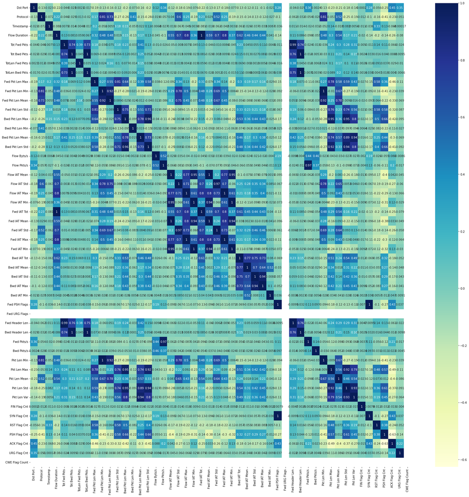

```python
from matplotlib import pyplot as plt
import seaborn as sns
fig= plt.figure(figsize=(30,30))
sns.heatmap(X_data.corr(), annot=True,cmap="YlGnBu")
```

```python
def get_correlation_high(X_data,threshold): #Findout the features with the correlation value greater the 0.85
    corr_col=set()
    corrmat=X_data.corr()
    for i in range(len(corrmat.columns)):
        for j in range(i):
            if abs(corrmat.iloc[i,j])>threshold:
                colname=corrmat.columns[i]
                corr_col.add(colname)
    return corr_col
```

```python
corelated_features=get_correlation_high(X_data,0.95) #spot the highly co realted features in the dataset
corelated_features
```

```
{'Bwd Header Len',
 'Bwd Pkt Len Std',
 'Flow IAT Min',
 'Fwd Header Len',
 'Fwd IAT Max',
 'Fwd IAT Mean',
 'Fwd IAT Min',
 'Fwd IAT Std',
 'Fwd IAT Tot',
 'Fwd Pkts/s',
 'Pkt Len Max',
 'Pkt Len Min',
 'SYN Flag Cnt',
 'TotLen Bwd Pkts'}
```

```python
corr=list(corelated_features)
corr
```

```
['Flow IAT Min',
 'Fwd IAT Tot',
 'Fwd IAT Min',
 'SYN Flag Cnt',
 'Pkt Len Min',
 'Fwd IAT Mean',
 'TotLen Bwd Pkts',
 'Bwd Header Len',
 'Pkt Len Max',
 'Fwd IAT Std',
 'Fwd Header Len',
 'Fwd Pkts/s',
 'Fwd IAT Max',
 'Bwd Pkt Len Std']
```

```python
for i in corr: #dropping the highly corelated features from the dataset
  final_dataset.drop(labels=[i],axis=1,inplace=True)
```

```python
final_dataset.shape
```

```
(19989, 37)
```

```python
final_dataset.columns
```

```
Index(['Dst Port', 'Protocol', 'Timestamp', 'Flow Duration', 'Tot Fwd Pkts',
       'Tot Bwd Pkts', 'TotLen Fwd Pkts', 'Fwd Pkt Len Max', 'Fwd Pkt Len Min',
       'Fwd Pkt Len Mean', 'Fwd Pkt Len Std', 'Bwd Pkt Len Max',
       'Bwd Pkt Len Min', 'Bwd Pkt Len Mean', 'Flow Byts/s', 'Flow Pkts/s',
       'Flow IAT Mean', 'Flow IAT Std', 'Flow IAT Max', 'Bwd IAT Tot',
       'Bwd IAT Mean', 'Bwd IAT Std', 'Bwd IAT Max', 'Bwd IAT Min',
       'Fwd PSH Flags', 'Fwd URG Flags', 'Bwd Pkts/s', 'Pkt Len Mean',
       'Pkt Len Std', 'Pkt Len Var', 'FIN Flag Cnt', 'RST Flag Cnt',
       'PSH Flag Cnt', 'ACK Flag Cnt', 'URG Flag Cnt', 'CWE Flag Count',
       'Label'],
      dtype='object')
```

# 4. Modeling

4.1 Splitting the datset to train and test

```python
y = final_dataset['Label'] #Splitting the Xi and Yi to apply the Permutation Importance model and identify the importanat features to further apply model
X = final_dataset.drop(['Label'],axis=1)

X_train, X_test, y_train, y_test = train_test_split(X,y,test_size = 0.30, random_state = 101)
```

```python
from xgboost import XGBClassifier

xgb = XGBClassifier(n_estimators=100)
xgb.fit(X_train, y_train)
```

[output not shown]

[output not shown]

```
XGBClassifier(base_score=0.5, booster='gbtree', colsample_bylevel=1,
              colsample_bynode=1, colsample_bytree=1, enable_categorical=False,
              gamma=0, gpu_id=-1, importance_type=None,
              interaction_constraints='', learning_rate=0.300000012,
              max_delta_step=0, max_depth=6, min_child_weight=1, missing=nan,
              monotone_constraints='()', n_estimators=100, n_jobs=8,
              num_parallel_tree=1, predictor='auto', random_state=0,
              reg_alpha=0, reg_lambda=1, scale_pos_weight=1, subsample=1,
              tree_method='exact', validate_parameters=1, verbosity=None)
```

```python
from sklearn.metrics import confusion_matrix, make_scorer, accuracy_score
XGBpredictions = xgb.predict(X_test)
print('the accuracy of SCG Classfier with hinge loss:',accuracy_score(y_test,XGBpredictions))
```

```
the accuracy of SCG Classfier with hinge loss: 0.9984992496248124
```

```python
from sklearn.ensemble import AdaBoostClassifier
from sklearn.tree import DecisionTreeClassifier
ADBClassifier = AdaBoostClassifier(DecisionTreeClassifier(max_depth=1),n_estimators=200)
ADBClassifier.fit(X_train, y_train)
```

```
AdaBoostClassifier(base_estimator=DecisionTreeClassifier(max_depth=1),
                   n_estimators=200)
```

```python
ADBCpredictions = ADBClassifier.predict(X_test)
print('the accuracy of SCG Classfier with hinge loss:',accuracy_score(y_test,ADBCpredictions))
```

```
the accuracy of SCG Classfier with hinge loss: 0.9998332499583125
```

4.2 Applying the Standard SVC model and checking the performance metrices

```python
from sklearn.svm import SVC
model = SVC()
model.fit(X_train, y_train)
```

```
SVC()
```

```python
from sklearn.metrics import confusion_matrix, make_scorer, accuracy_score
predictions = model.predict(X_test)
from sklearn.metrics import classification_report, confusion_matrix
print('the accuracy of Standard SVC:',accuracy_score(y_test,predictions))

print(classification_report(y_test, predictions))
```

```
the accuracy of Standard SVC: 0.9953309988327497
              precision    recall  f1-score   support

           0       1.00      1.00      1.00      5969
           1       0.00      0.00      0.00        28

    accuracy                           1.00      5997
   macro avg       0.50      0.50      0.50      5997
weighted avg       0.99      1.00      0.99      5997
```

[output not shown]

Observation:

4.3 Applying the SGD Classifier with Hinge Loss

```python
from sklearn.linear_model import SGDClassifier
SGDmodel = SGDClassifier(loss="hinge", penalty="l2")
SGDmodel.fit(X_train, y_train)
```

```
SGDClassifier()
```

```python
from sklearn.metrics import confusion_matrix, make_scorer, accuracy_score
SGDpredictions = SGDmodel.predict(X_test)
print('the accuracy of SCG Classfier with hinge loss:',accuracy_score(y_test,SGDpredictions))
```

```
the accuracy of SCG Classfier with hinge loss: 0.9953309988327497
```

Observations:

The model performance is worse by appying the SGD classifier with hinge loss. Appyling SGD for this dataset will not be the best idea here

4.4 Applying the SGD Classifier with Hinge Loss on different iterations

```python
n_iters = [5, 10, 20, 50, 100, 1000]
scores = []
for n_iter in n_iters:
    SGDmodel = SGDClassifier(loss="hinge", penalty="l2", max_iter=n_iter)
    SGDmodel.fit(X_train, y_train)
    SGDpredictions = SGDmodel.predict(X_test)
    scores.append(accuracy_score(y_test,SGDpredictions))

plt.title("Effect of n_iter")
plt.xlabel("n_iter")
plt.ylabel("score")
plt.plot(n_iters, scores)
```

[output not shown]

Observations:

1. The performance of the SVM SGD with hinge loss on diifrent iteration is also very poor.
2. With different iterations the performance is not improving , with increasing iterations the model score is staying stagnent here.

4.5 Applying the Logistic regression SGD Classifier with Log Loss on different iterations

```python
n_iters = [5, 10, 20, 50, 100, 1000]
scores = []
for n_iter in n_iters:
    SGDmodel = SGDClassifier(loss="log", penalty="l2", max_iter=n_iter)
    SGDmodel.fit(X_train, y_train)
    SGDpredictions = SGDmodel.predict(X_test)
    scores.append(accuracy_score(y_test,SGDpredictions))

plt.title("Effect of n_iter")
plt.xlabel("n_iter")
plt.ylabel("score")
plt.plot(n_iters, scores)
```

[output not shown]

Observations:

1. With SGD Log loss the score is still worse, the accuracy is poor with diffrent iterations
2. The Accuracy score has stopped increasing after iterations

4.6 Applying the Decsion Trees

```python
from sklearn.tree import DecisionTreeClassifier
DT_clf = DecisionTreeClassifier(random_state=0)

DT_clf.fit(X_train, y_train)
DT_pred=DT_clf.predict(X_test)
print('the accuracy',accuracy_score(y_test,DT_pred))
```

```
the accuracy 0.9978322494580624
```

```python
from sklearn.metrics import classification_report, confusion_matrix
confusion_matrix(y_test,DT_pred)
```

```
array([[5966,    3],
       [  10,   18]], dtype=int64)
```

```python
print(classification_report(y_test, DT_pred))
```

```
              precision    recall  f1-score   support

           0       1.00      1.00      1.00      5969
           1       0.86      0.64      0.73        28

    accuracy                           1.00      5997
   macro avg       0.93      0.82      0.87      5997
weighted avg       1.00      1.00      1.00      5997
```

Observations:

1. The DT Algorithm seems to be performing better than the other SVM and LR models.
2. The model is producing better accuracy score that by applying SVM and LR
3. With confusion matrix we could see that the model is separating the bening and anamlous requests in a decent way.

```python
from sklearn.tree import DecisionTreeClassifier as DT
from sklearn.model_selection import GridSearchCV

parameters = {'max_depth':[1,5,10,50],'min_samples_split':[5,10,100,500]}
DTclf= GridSearchCV(DT(),parameters)
DTclf.fit(X_train, y_train)
```

```
GridSearchCV(estimator=DecisionTreeClassifier(),
             param_grid={'max_depth': [1, 5, 10, 50],
                         'min_samples_split': [5, 10, 100, 500]})
```

```python
print('Best score: ',DTclf.best_score_)
print('Parameters with best score: ',DTclf.best_params_)
```

```
Best score:  0.9979273461547203
Parameters with best score:  {'max_depth': 50, 'min_samples_split': 5}
```

```python
Best_DT_clf = DT(max_depth=50, min_samples_split=10, random_state=0)
Best_DT_clf.fit(X_train, y_train)
H_DT_pred=Best_DT_clf.predict(X_test)
print('the accuracy',accuracy_score(y_test,H_DT_pred))
```

```
the accuracy 0.9976654994163748
```

```python
from sklearn.metrics import classification_report, confusion_matrix
confusion_matrix(y_test,DT_pred)
```

```
array([[5966,    3],
       [  10,   18]], dtype=int64)
```

```python
print(classification_report(y_test, DT_pred))
```

```
              precision    recall  f1-score   support

           0       1.00      1.00      1.00      5969
           1       0.86      0.64      0.73        28

    accuracy                           1.00      5997
   macro avg       0.93      0.82      0.87      5997
weighted avg       1.00      1.00      1.00      5997
```

Observation:

```python
from sklearn.ensemble import RandomForestClassifier
RF_model = RandomForestClassifier(n_estimators=100,random_state=0).fit(X_train, y_train)
RF_pred=RF_model.predict(X_test)
print('the accuracy of RF model',accuracy_score(y_test,RF_pred))
```

```
the accuracy of RF model 0.9983324995831249
```

```python
from sklearn.metrics import classification_report, confusion_matrix
confusion_matrix(y_test,RF_pred)
```

```
array([[5969,    0],
       [  10,   18]], dtype=int64)
```

```python
print(classification_report(y_test, RF_pred))
```

```
              precision    recall  f1-score   support

           0       1.00      1.00      1.00      5969
           1       1.00      0.64      0.78        28

    accuracy                           1.00      5997
   macro avg       1.00      0.82      0.89      5997
weighted avg       1.00      1.00      1.00      5997
```

Observation:

**Ensembling**

```python
y = final_dataset['Label'] #Splitting the Xi and Yi for ensembling
X = final_dataset.drop(['Label'],axis=1)
```

```python
X1_train, X1_test, y1_train, y1_test = train_test_split(X,y,test_size = 0.2, random_state = 101)  #Doing the 80-20 split
```

```python
data = pd.concat([X1_train, y1_train], axis=1) #taking the 80 split alone
data.shape
```

```
(15991, 37)
```

```python
EightyPer_Y=data['Label'] #seperating the class labels from 80% split
EightyPer_X=data.drop(['Label'],axis=1)
D1_X, D2_X, D1_Y, D2_Y = train_test_split(EightyPer_X,EightyPer_Y,test_size = 0.5, random_state = 101) #Doing the 50-50 split on the 80% datset
```

```python
D1=pd.concat([D1_X,D1_Y],axis=1) #Forming D1 and D2
D1.shape
print('the shape of D1',D1.shape)
D2=pd.concat([D2_X,D2_Y],axis=1)
print('the shape of D2',D2.shape)
```

```
the shape of D1 (7995, 37)
the shape of D2 (7996, 37)
```

```python
S1=D1.sample(n=60908, replace=True, random_state=1) # sampling with replacement on D1 dataset #taking 6 sample sets
S2=D1.sample(n=60908, replace=True, random_state=1)
S3=D1.sample(n=60908, replace=True, random_state=1)
S4=D1.sample(n=60908, replace=True, random_state=1)
S5=D1.sample(n=60908, replace=True, random_state=1)
S6=D1.sample(n=60908, replace=True, random_state=1)
```

```python
S1y = S1['Label']  #samples and its coressponding class labels
S1X = S1.drop(['Label'],axis=1)
S2y = S2['Label']
S2X = S2.drop(['Label'],axis=1)
S3y = S3['Label']
S3X = S3.drop(['Label'],axis=1)
S4y = S4['Label']
S4X = S4.drop(['Label'],axis=1)
S5y = S5['Label']
S5X = S5.drop(['Label'],axis=1)
S6y = S6['Label']
S6X = S6.drop(['Label'],axis=1)
```

```python
from sklearn.tree import DecisionTreeClassifier #fitting the base model DT with then D1 samples
Base_model=DecisionTreeClassifier()

BS1=Base_model.fit(S1X,S1y)
BS2=Base_model.fit(S2X,S2y)
BS3=Base_model.fit(S3X,S3y)
BS4=Base_model.fit(S4X,S4y)
BS5=Base_model.fit(S5X,S5y)
BS6=Base_model.fit(S6X,S6y)
```

```python
model1=Base_model.predict(D2_X) #passing the D2 train to get model predict
model2=Base_model.predict(D2_X)
model3=Base_model.predict(D2_X)
model4=Base_model.predict(D2_X)
model5=Base_model.predict(D2_X)
model6=Base_model.predict(D2_X)
```

```python
BS1=model1.reshape(-1,1)
BS2=model2.reshape(-1,1)
BS3=model3.reshape(-1,1)
BS4=model4.reshape(-1,1)
BS5=model5.reshape(-1,1)
BS6=model6.reshape(-1,1)
```

```python
D_meta = np.vstack((BS1,BS2,BS3,BS4,BS5,BS6)) #creating Dataset out of the n-models predictions
print('The length of the D_meta data',len(D_meta))
D_meta_data=D_meta[:60908] #sampling only the required datapoints
print('Lenght of meta data post Sampling ',len(D_meta_data))
```

```
The length of the D_meta data 47976
Lenght of meta data post Sampling  47976
```

```python
from xgboost import XGBClassifier #taking the XGB as the meta model and passing the meta data and the D2 class labels

xgb = XGBClassifier(n_estimators=100)
xgb.fit(D_meta_data, D2_Y)
```

```python
test_pred1=Base_model.predict(X1_test) #passing 20 percent test data which was split at the first stage
test_pred2=Base_model.predict(X1_test)
test_pred3=Base_model.predict(X1_test)
test_pred4=Base_model.predict(X1_test)
test_pred5=Base_model.predict(X1_test)
test_pred6=Base_model.predict(X1_test)
```

```python
TP1=test_pred1.reshape(-1,1) #test prediction results
TP2=test_pred2.reshape(-1,1)
TP3=test_pred3.reshape(-1,1)
TP4=test_pred4.reshape(-1,1)
TP5=test_pred5.reshape(-1,1)
TP6=test_pred6.reshape(-1,1)
```

```python
D_test_meta = np.vstack((TP1,TP2,TP3,TP4,TP5,TP6)) #Stacking up the test prediction results
```

```python
D_test_meta=D_test_meta[:30455]
```

```python
pred_final = xgb.predict(D_test_meta) #passing the final dataset to the meta model
```

**Custom Implementation**

```python
Y=pd.DataFrame(final_dataset['Label'],columns=['Label']) #Splitting the Xi and Yi for ensembling
X = final_dataset.drop(['Label'],axis=1)
```

```python
X1_train, X1_test, y1_train, y1_test = train_test_split(X,y,test_size = 0.2, random_state = 101) #Doing the 80-20 split
```

```python
def sampling(n_estimators,D1_data):#sampling Randomly
  size=len(D1_data)
  samples=[]
  for i in range(n_estimators):
    S=D1_data.sample(n=size, replace=True, random_state=60000)
    samples.append(S)
  return samples

def splitting(samples,n_estimators):#splitting Xi and Yi
  Xi=[]
  Yi=[]
  for i in range(n_estimators):
    a=samples[i]
    S_Yi=a['Label']
    S_Xi=a.drop(['Label'],axis=1)

    Xi.append(S_Xi)
    Yi.append(S_Yi)
  return Xi,Yi

def modeling(n_estimators,Xi,Yi): #training on the base model
  from sklearn.tree import DecisionTreeClassifier
  Base_model=DecisionTreeClassifier()

  for i in range(n_estimators):
    BS=Base_model.fit(Xi[i],Yi[i])

  return BS

def base_pred(BS,D2_X_test,n_estimators):#pred DT with D2_X_test
  samples_prediction=[]

  for i in range(n_estimators):
    predictions=BS.predict(D2_X_test)
    samples_prediction.append(predictions)

  return samples_prediction



def reshape(samples_prediction,n_estimators):#reshape
  SP_meta=[]
  for i in range(n_estimators):
    SP_meta=samples_prediction[i].reshape(-1,1)
  return SP_meta

def xgb_model(meta_samples,D2_Y_test): #XGB
  from xgboost import XGBClassifier

  meta= XGBClassifier(n_estimators=100)
  meta.fit(meta_samples, D2_Y_test)

  return meta



def test_pred(Base_models,twenty_test_pred,n_estimators):#test pred

  test_prediction=[]
  for i in range(n_estimators):
    predictions=Base_models.predict(X_test)
    test_prediction.append(predictions)

  return test_prediction



def custom_ensemble(X_train,y_train,X_test,y1_test,n_estimators):

  D1_X_train,D2_X_test,D1_Y_train,D2_Y_test=train_test_split(X_train,y_train,test_size = 0.5) #doing 50-50 split


  D1_data=pd.concat([D1_X_train,D1_Y_train],axis=1)
  D2_data=pd.concat([D2_X_test,D2_Y_test],axis=1)

  D_samples=sampling(n_estimators,D1_data)#sampling from D1
  Xi,Yi=splitting(D_samples,n_estimators)#split xi and yi of the samples
  Base_models=modeling(n_estimators,Xi,Yi)#training the DT model with the samples
  samples_prediction=base_pred(Base_models,D2_X_test,n_estimators)#precicting using the D2 test
  meta_samples=reshape(samples_prediction,n_estimators)#reshape
  meta_model=xgb_model(meta_samples,D2_Y_test)#calling XGB model
  twenty_test_pred=base_pred(Base_models,X_test,n_estimators)
  tp_samples=reshape(twenty_test_pred,n_estimators)#reshape
  pred_final = meta_model.predict(tp_samples)
  from sklearn.metrics import accuracy_score
  acc=accuracy_score(y1_test,pred_final)

  print('the accuracy for the custom ensemble implementation',acc)
```

```python
custom_ensemble(X1_train,y1_train,X1_test,y1_test,40)
```

```
c:\Program Files\Python36\lib\site-packages\xgboost\sklearn.py:1224: UserWarning: The use of label encoder in XGBClassifier is deprecated and will be removed in a future release. To remove this warning, do the following: 1) Pass option use_label_encoder=False when constructing XGBClassifier object; …
  warnings.warn(label_encoder_deprecation_msg, UserWarning)
```

```
[23:56:44] WARNING: C:/Users/Administrator/workspace/xgboost-win64_release_1.5.1/src/learner.cc:1115: Starting in XGBoost 1.3.0, the default evaluation metric used with the objective 'binary:logistic' was changed from 'error' to 'logloss'. Explicitly set eval_metric if you'd like to restore the old …
the accuracy for the custom ensemble implementation 0.9964982491245623
```